# Hierarchical Clustering

Erik Larsen

2026-03-29

# Overview

This markdown was developed to formally document an ad-hoc cluster analysis for TMEM184B immunoprecipitation tandem mass-spec experiments for **Dr. Martha Bhattacharya’s lab** at the **University of Arizona** for the endolysosomal paper under revision (2025-02-28) for the Journal of Cell Science

This vignette documents the `Hierarchical Clustering` of this IPMS data

## Attach Packages

```r
# data/wrangling
library(tidyverse)
library(Endo)
library(DT)

# clustering
library(pheatmap)
library(dynamicTreeCut)

# GSEA/viz
library(clusterProfiler)
library(org.Hs.eg.db)
library(ReactomePA)
library(AnnotationDbi)

# progress bar
library(progressr)

# parallelization
library(future)
library(future.apply)

# network viz
library(visNetwork)

options(stringsAsFactors = FALSE)
```

## Load the Pre-Computed Data

- Classify each protein into a matrix based on its `hSAINT` score and number of contamination flags (**0**, **1**, **2**)

```r
# Load precomputed objects from preprocessing
load("R/precompute_objects.rda")
```

```r
mean_shift_valley <- function(gamma_vec) {

  # kernel density estimate on [0,1]
  d <- stats::density(gamma_vec, from = 0, to = 1)

  # tibble with density and neighbors for derivative and mode detection
  df <- tibble::tibble(
    x       = d$x,
    f       = d$y,
    f_lag   = dplyr::lag(d$y),      # f[i-1]
    f_lead  = dplyr::lead(d$y)      # f[i+1]
  )

  # discrete derivative of the density (forward difference)
  # slope[i] approximates f'(x[i])
  df <- df %>%
    dplyr::mutate(
      slope = f_lead - f
    )

  # indices where both neighbors exist (needed for local maxima)
  df <- df %>%
    dplyr::mutate(
      interior = !is.na(f_lag) & !is.na(f_lead)
    )

  # local maxima (aka modes) satisfy f > f_lag and f > f_lead
  df <- df %>%
    dplyr::mutate(
      is_mode = interior & f > f_lag & f > f_lead
    )

  # extract mode indices
  mode_idx <- which(df$is_mode)

  # assume two modes: left (noise) and right (signal)
  left_mode  <- mode_idx[1]
  right_mode <- mode_idx[length(mode_idx)]

  # mean-shift basin assignment:
  # each grid point moves uphill following the sign of the slope
  basin_target <- integer(nrow(df))

  for (i in seq_len(nrow(df))) {
    j <- i
    # move right while slope is positive
    while (j < nrow(df) && df$slope[j] > 0) {
      j <- j + 1
    }
    # move left while slope is negative
    while (j > 1 && df$slope[j - 1] < 0) {
      j <- j - 1
    }
    basin_target[i] <- j
  }

  # classify each point by which mode it's closer to
  left_dist  <- abs(basin_target - left_mode)
  right_dist <- abs(basin_target - right_mode)

  class_label <- ifelse(left_dist < right_dist, 1L, 2L)

  # valley boundary is the last index classified as left
  boundary_idx <- max(which(class_label == 1L))

  # valley location (single point)
  c <- df$x[boundary_idx]

  # expand valley asymmetrically using slope magnitude
  # threshold is relative to max slope magnitude
  eps <- 0.01 * max(abs(df$slope), na.rm = TRUE)

  left_idx <- boundary_idx
  while (left_idx > 1 && abs(df$slope[left_idx - 1]) < eps) {
    left_idx <- left_idx - 1
  }

  right_idx <- boundary_idx
  while (right_idx < nrow(df) && abs(df$slope[right_idx]) < eps) {
    right_idx <- right_idx + 1
  }

  c1 <- df$x[left_idx]
  c2 <- df$x[right_idx]

  c(c1, c2)
}
```

```r
hSAINT <- hSAINT |>
  dplyr::mutate(
    hSAINT_class = {
      cutpoints <- mean_shift_valley(score) # find the indeces of the class modes bounding the valley between them
      dplyr::case_when(
        score < cutpoints[1] ~ 'Low hSAINT', # assign classes based on post. prob
        score <= cutpoints[2] ~ 'Medium hSAINT',
        score > cutpoints[2] ~ 'High hSAINT'
      )
    },
    contam_flag = lit_flag + CRAPome_flag,

    # assign contamination class based on frequency across shared studies and id in lit
    contam_class = dplyr::case_when(contam_flag == 0 ~
                                              'Low Contamination',
                                            contam_flag == 1 ~
                                              'Medium Contamination',
                                            contam_flag == 2 ~
                                              'High Contamination'),

    stat_class = paste(hSAINT_class,
                               contam_class, sep = ', ')
  ) |> # assign the orthogonal statistical model-based classes

  dplyr::rename(hSAINT_score = score) |>
  dplyr::relocate(contam_flag, .after = hSAINT_score) |>
  dplyr::select(-hSAINT_class, -contam_class) |>
  dplyr::rename_with(.cols = c(!dplyr::contains('Protein')), ~paste0('protein_', .x))

head(hSAINT)
```

```
## # A tibble: 6 × 6
##   Protein protein_hSAINT_score protein_contam_flag protein_lit_flag
##   <chr>                  <dbl>               <dbl>            <dbl>
## 1 ABCD3                  1.000                   1                0
## 2 ABCE1                  1.000                   0                0
## 3 ABCF2                  1.000                   0                0
## 4 ACACA                  1.000                   0                0
## 5 ACLY                   1.000                   0                0
## 6 ACTC1                  1.000                   0                0
## # ℹ 2 more variables: protein_CRAPome_flag <dbl>, protein_stat_class <chr>
```

# Hierarchical Clustering

## Raw Counts

```r
d <- stats::as.dist(1 - stats::cor(t(IPMS_mat), use = 'pairwise.complete.obs'))
hc <- stats::hclust(d, method = "average")
```

- Perform a grid search to assess the optimal `hierarchical dendrogram tree cut height`

```r
sizes <- c(20, 30, 50, 80, 100)
results <- list()

for (m in sizes) {
  cl <- dynamicTreeCut::cutreeDynamic(
    dendro = hc,
    distM = as.matrix(d),
    deepSplit = 1,
    pamRespectsDendro = TRUE,
    minClusterSize = m
  )
  results[[as.character(m)]] <- cl
  cat("minClusterSize =", m, "→", length(table(cl)), "clusters\n")
}
```

```
##  ..cutHeight not given, setting it to 0.976  ===>  99% of the (truncated) height range in dendro.
##  ..done.
## minClusterSize = 20 → 50 clusters
##  ..cutHeight not given, setting it to 0.976  ===>  99% of the (truncated) height range in dendro.
##  ..done.
## minClusterSize = 30 → 42 clusters
##  ..cutHeight not given, setting it to 0.976  ===>  99% of the (truncated) height range in dendro.
##  ..done.
## minClusterSize = 50 → 28 clusters
##  ..cutHeight not given, setting it to 0.976  ===>  99% of the (truncated) height range in dendro.
##  ..done.
## minClusterSize = 80 → 21 clusters
##  ..cutHeight not given, setting it to 0.976  ===>  99% of the (truncated) height range in dendro.
##  ..done.
## minClusterSize = 100 → 17 clusters
```

```r
rm(list = c('cl', 'm', 'sizes', 'results'))
```

- `optimal minimum cluster size` is **50** (elbow; diminishing returns after)
- `# clusters` = **28**

```r
clusters_opt <- dynamicTreeCut::cutreeDynamic(hc,
                                              distM = as.matrix(d),
                                              deepSplit = 1,
                                              pamRespectsDendro = T,
                                              minClusterSize = 50)
```

```
##  ..cutHeight not given, setting it to 0.976  ===>  99% of the (truncated) height range in dendro.
##  ..done.
```

```r
names(clusters_opt) <- rownames(IPMS_mat)
```

```r
cluster_ids <- sort(unique(clusters_opt))
cluster_colors <- stats::setNames(
  grDevices::rainbow(length(cluster_ids), s = 0.6, v = 0.9),
  cluster_ids
)

annotation_colors <- list(cluster = cluster_colors)
```

Sparse data is too difficult to discern from a global view

-> Z transform the raw counts **after clustering** to plot

- the cluster object preserves the ordering of the proteins (dendrogram)
  - Z-score therefore only changes the values of the columns and rows to better visualize the sparse data

```r
IPMS_z <- t(scale(t(IPMS_mat)))
colnames(IPMS_z) <- colnames(IPMS_mat)

condition <- sub('_.*', '', colnames(IPMS_mat))

col_order <- unlist(
  lapply(
    split(seq_along(condition), condition), function(idx) {
      submat <- IPMS_z[, idx, drop = FALSE]
      hc_sub <- stats::hclust(stats::dist(t(submat)), method = 'ward.D2')
      idx[hc_sub$order]
    }))

IPMS_z_ordered <- IPMS_z[, col_order]

rm(list = c('condition', 'col_order'))
```

# Cluster Descriptions

- In order to assess this clustering method and to also compare/validate the `hierarchical SAINT Poisson mixture model`, describing clusters based on the proteins within them is useful
- Similarly-localized proteins could be expected to have similar abundances to each other as well as the target (**TMEM184B**)
- Similarly-functioning proteins could also be expected to have similar abundances to each other as well as the target
- Describing these clusters attained by `hierarchical clustering` via gene ontology gene set enrichment analysis is, therefore, useful and standard practice
- Furthermore, we may be able to assemble a `protein-protein interaction network` from the results
- We outline this below– the methods and results for acquiring these clusters, their constituent proteins, and how we make sense of them– visualized as `dotplots`, `heatmaps`, and a `network`
- We include searchable tables printed last

## Extract Clusters

Extract gene names from the hierarchically-clustered clusters and convert to a dataframe

```r
clusters_list_idx <- lapply(sort(unique(clusters_opt)), function(m) {
  which(clusters_opt == m)
})
names(clusters_list_idx) <- sort(unique(clusters_opt))

clusters_list <- lapply(sort(unique(clusters_opt)), function(m) {
  rownames(IPMS_mat)[clusters_opt == m]
})
names(clusters_list) <- sort(unique(clusters_opt)) |> as.character()

clusters_df <- clusters_list %>%
  purrr::map_df(., .f = as.data.frame, .id = 'cluster') |>
  dplyr::rename(Protein = 2) |>
  dplyr::relocate(Protein, .before = 1)
```

## Compute Cluster Summaries

- Include score summaries (mean and median `hSAINT score`s, ranks, and contamination rates)

```r
cluster_scores <- clusters_df |>
  dplyr::inner_join(
    hSAINT
  ) |>
  dplyr::arrange(desc(protein_hSAINT_score)) |>
  dplyr::group_by(cluster) |>
  dplyr::summarize(
    # compute summary metrics
    cluster_mean_hSAINT_score = mean(protein_hSAINT_score),
    cluster_median_hSAINT_score = stats::median(protein_hSAINT_score),
    cluster_hSAINT_score_mass = sum(protein_hSAINT_score),
    cluster_size = dplyr::n(),
    cluster_lit_flag_perc = (sum(protein_lit_flag)/cluster_size)*100,
    cluster_CRAPome_flag_perc = (sum(protein_CRAPome_flag)/cluster_size)*100,
    cluster_contam_perc = cluster_lit_flag_perc + cluster_CRAPome_flag_perc) |>

  dplyr::arrange(desc(cluster_mean_hSAINT_score), cluster_contam_perc) |>
  dplyr::mutate(cluster_mean_rank = dplyr::row_number()) |>
  dplyr::arrange(desc(cluster_median_hSAINT_score), cluster_contam_perc) |>
  dplyr::mutate(cluster_median_rank = dplyr::row_number()) |>
  dplyr::arrange(desc(cluster_hSAINT_score_mass), cluster_contam_perc) |>
  dplyr::mutate(cluster_total_rank = dplyr::row_number()) |>
  dplyr::arrange(cluster_mean_rank) |>
  dplyr::relocate(c(cluster_lit_flag_perc,
                    cluster_CRAPome_flag_perc), .after = cluster_total_rank) |>
  # apply mean shift function for classification; contamination is not bi-modal
  dplyr::mutate(
    cluster_hSAINT_class = {
      cutpoints <- mean_shift_valley(cluster_median_hSAINT_score) # find the indeces of the class modes
      dplyr::case_when(
        cluster_median_hSAINT_score < cutpoints[1] ~ 'Low hSAINT', # assign classes based on post. prob
        cluster_median_hSAINT_score <= cutpoints[2] ~ 'Medium hSAINT',
        cluster_median_hSAINT_score > cutpoints[2] ~ 'High hSAINT'
      )
    },
    cluster_contam_class = dplyr::case_when(
      cluster_contam_perc <= stats::quantile(
        cluster_contam_perc, 0.60) ~ "Low Contamination",
      cluster_contam_perc <= stats::quantile(
        cluster_contam_perc, 0.95) ~ "Medium Contamination",
      TRUE ~ "High Contamination"
    ),


    cluster_class = paste(cluster_hSAINT_class,
                          cluster_contam_class, sep = ', ')
  ) |>
  dplyr::select(-cluster_hSAINT_class, -cluster_contam_class) |>
  dplyr::relocate(cluster_class, .after = cluster)

head(cluster_scores)
```

```
## # A tibble: 6 × 12
##   cluster cluster_class            cluster_mean_hSAINT_…¹ cluster_median_hSAIN…²
##   <chr>   <chr>                                     <dbl>                  <dbl>
## 1 2       High hSAINT, Medium Con…                  0.748                  0.997
## 2 1       High hSAINT, High Conta…                  0.689                  0.985
## 3 7       High hSAINT, Medium Con…                  0.644                  0.932
## 4 9       High hSAINT, Low Contam…                  0.579                  0.768
## 5 25      High hSAINT, High Conta…                  0.533                  0.561
## 6 15      Low hSAINT, Low Contami…                  0.475                  0.328
## # ℹ abbreviated names: ¹cluster_mean_hSAINT_score, ²cluster_median_hSAINT_score
## # ℹ 8 more variables: cluster_hSAINT_score_mass <dbl>, cluster_size <int>,
## #   cluster_contam_perc <dbl>, cluster_mean_rank <int>,
## #   cluster_median_rank <int>, cluster_total_rank <int>,
## #   cluster_lit_flag_perc <dbl>, cluster_CRAPome_flag_perc <dbl>
```

### Cluster Distributions of hSAINT and Contamination Scores

- Plot the distributions of metrics describing clusters, independent of `GO Terms`

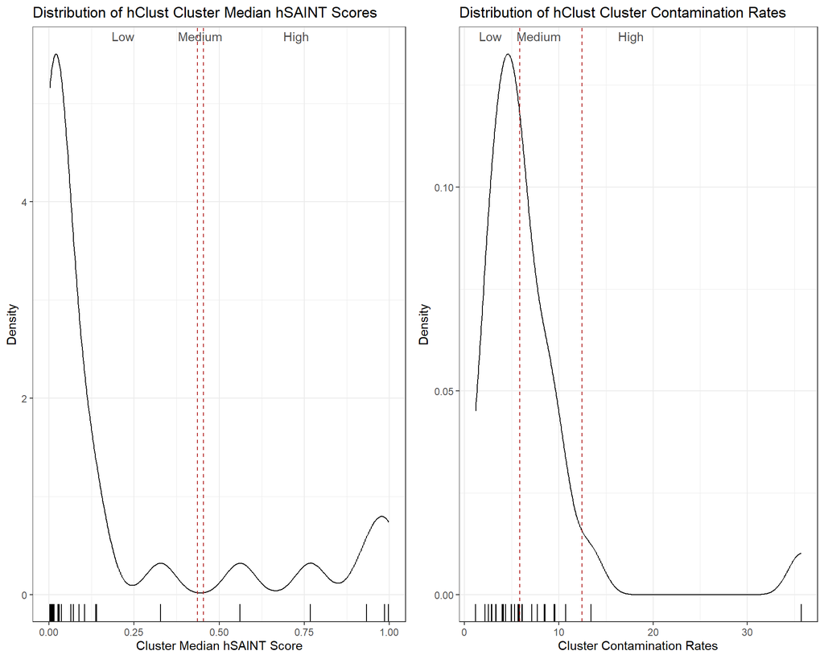

```r
# extract the cluster median hSAINT score distribution class indeces
hSAINT_cuts <- mean_shift_valley(cluster_scores$cluster_median_hSAINT_score)

cowplot::plot_grid(
  cluster_scores |>
    dplyr::group_by(cluster) |>
    ggplot2::ggplot(ggplot2::aes(x = cluster_median_hSAINT_score)) +
    ggplot2::geom_density() +
    ggplot2::geom_rug() +
    ggplot2::theme_bw() +
    ggplot2::labs(title = 'Distribution of hClust Cluster Median hSAINT Scores',
                  x = 'Cluster Median hSAINT Score',
                  y = 'Density') +
    ggplot2::geom_vline(
      xintercept = hSAINT_cuts,
      linetype = 'dashed',
      color = 'firebrick'
    ) + ggplot2::annotate(
    "text",
    x = hSAINT_cuts[1] / 2,
    y = Inf, vjust = 1.5,
    label = "Low", color = "gray30"
  ) +
  ggplot2::annotate(
    "text",
    x = mean(hSAINT_cuts),
    y = Inf, vjust = 1.5,
    label = "Medium", color = "gray30"
  ) +
  ggplot2::annotate(
    "text",
    x = (hSAINT_cuts[2] + max(cluster_scores$cluster_median_hSAINT_score)) / 2,
    y = Inf, vjust = 1.5,
    label = "High", color = "gray30"
  ),

  cluster_scores |>
    dplyr::group_by(cluster) |>
    ggplot2::ggplot(ggplot2::aes(x = cluster_contam_perc)) +
    ggplot2::geom_density() +
    ggplot2::geom_rug() +
    ggplot2::theme_bw() +
    ggplot2::labs(title = 'Distribution of hClust Cluster Contamination Rates',
                  x = 'Cluster Contamination Rates',
                  y = 'Density') +
    ggplot2::geom_vline(
      xintercept = stats::quantile(cluster_scores |>
                                     dplyr::pull(cluster_contam_perc),
                                   c(0.60, 0.95),
                                   na.rm = T),
      linetype = 'dashed',
      color = 'firebrick'
    )  +
  ggplot2::annotate("text",
    x = stats::quantile(cluster_scores$cluster_contam_perc, 0.10),
    y = Inf, vjust = 1.5, label = "Low", color = "gray30"
  ) +
  ggplot2::annotate("text",
    x = stats::quantile(cluster_scores$cluster_contam_perc, 0.75),
    y = Inf, vjust = 1.5, label = "Medium", color = "gray30"
  ) +
  ggplot2::annotate("text",
    x = stats::quantile(cluster_scores$cluster_contam_perc, 0.97),
    y = Inf, vjust = 1.5, label = "High", color = "gray30"
  ),

  nrow = 1
)
```

- Gather all the data together:
  - Join the cluster scores data to the cluster (per protein) dataframe and the `hSAINT` results for classification

```r
protein_cluster_df <- clusters_df |>
  dplyr::inner_join(
    hSAINT
  ) |>
  dplyr::full_join(
    cluster_scores |>
      dplyr::ungroup()
  ) |>
  dplyr::mutate(dplyr::across(c(dplyr::where(is.double)), ~ round(.x, 3))) |>
  dplyr::relocate(cluster_class, .after = cluster) |>
  dplyr::arrange(desc(protein_hSAINT_score), Protein) |>
  dplyr::group_by(cluster) |>
  dplyr::ungroup()

head(protein_cluster_df)
```

```
## # A tibble: 6 × 18
##   Protein cluster cluster_class         protein_hSAINT_score protein_contam_flag
##   <chr>   <chr>   <chr>                                <dbl>               <dbl>
## 1 AAAS    1       High hSAINT, High Co…                    1                   0
## 2 AARS1   5       Low hSAINT, Low Cont…                    1                   0
## 3 AARS2   7       High hSAINT, Medium …                    1                   0
## 4 AASS    1       High hSAINT, High Co…                    1                   0
## 5 ABCB10  1       High hSAINT, High Co…                    1                   0
## 6 ABCB7   1       High hSAINT, High Co…                    1                   0
## # ℹ 13 more variables: protein_lit_flag <dbl>, protein_CRAPome_flag <dbl>,
## #   protein_stat_class <chr>, cluster_mean_hSAINT_score <dbl>,
## #   cluster_median_hSAINT_score <dbl>, cluster_hSAINT_score_mass <dbl>,
## #   cluster_size <int>, cluster_contam_perc <dbl>, cluster_mean_rank <int>,
## #   cluster_median_rank <int>, cluster_total_rank <int>,
## #   cluster_lit_flag_perc <dbl>, cluster_CRAPome_flag_perc <dbl>
```

## Cluster Classification Rationale

`Cluster median hSAINT scores`

- Scores exhibit a weak bi-modal distribution
- Applying 1‑D mean‑shift to the empirical density identifies a valley between **0.436** and **0.454**, the x-coordinates of the local minimum of the estimated density function
- We use this valley to define cluster-level `hSAINT` classes consistent with the mode-based classification used at the protein level (**Low**, **Mid** medium), **High**)

`Cluster contamination rates`

- Also uni-modal and right‑skewed, but with an extreme outlier
- Although the kernel density estimate shows a small secondary bump, this feature is driven the outlier and does *not* represent a true mode
  - Consistent with this, **mean-shift** valley detection fails to identify a density minimum, confirming that the distribution contains no data-derived boundaries
- To avoid imposing arbitrary boundaries for a consistent, three-tier classification paradigm, we classify contamination by isolating the extreme upper tail
  - Clusters in the bottom **60%** of contamination rates = **Low**
  - Clusters between **60th and 95th percentiles** = **Mid** (medium)
  - Clusters > 95% percentile = **High**
  - This approach separates the clean majority, the moderate tail, and the extreme outlier without fabricating structure not present in the data

## Cluster GO GSEA

```r
EntrezIDs <- AnnotationDbi::select(
  org.Hs.eg.db,
  keys = clusters_df |> dplyr::distinct(Protein) |> dplyr::pull(),
  columns = 'ENTREZID',
  keytype = 'SYMBOL'
) |>
  dplyr::filter(!is.na(2))

EntrezMap <- stats::setNames(EntrezIDs$ENTREZID, EntrezIDs$SYMBOL)
```

- Create enrichment functions

```r
background_genes <- EntrezIDs |> # use the EntrezIDs mapped from the modules_df
  dplyr::pull(ENTREZID)

get_GO <- function(genes, ontology, background_genes) {
  clusterProfiler::enrichGO(
    gene = genes,
    universe = background_genes,
    OrgDb = org.Hs.eg.db,
    keyType = 'ENTREZID',
    ont = ontology,
    pAdjustMethod = 'BH',
    qvalueCutoff = 0.05,
    readable = T
  )
}

get_kegg <- function(genes, EntrezMap) {
  entrez <- EntrezMap[genes]
  entrez <- entrez[!is.na(entrez)]
  if (length(entrez)==0) {
    return(NULL)
  }
  clusterProfiler::enrichKEGG(
    gene = entrez,
    organism = 'hsa',
    pAdjustMethod = 'BH',
    qvalueCutoff = 0.05
  )
}

get_reactome <- function(genes, EntrezMap) {
  entrez <- EntrezMap[genes]
  entrez <- entrez[!is.na(entrez)]
  if (length(entrez)==0) {
    return(NULL)
  }
  ReactomePA::enrichPathway(
    gene = entrez,
    organism = 'human',
    pAdjustMethod = 'BH',
    qvalueCutoff = 0.05,
    readable = T
  )
}
```

- Run the functions on the dataset in parallel (multiple CPUs)

```r
future::plan(future::multisession, workers = 6)

progressr::with_progress({

  cluster_ids <- sort(unique(clusters_df$cluster))

  p <- progressr::progressor(steps = length(cluster_ids))

    enrichment_results <- future.apply::future_lapply(
      cluster_ids,
      function(mod) {

        # tick progress IN THE MAIN SESSION
      p(sprintf("cluster %s", mod))

        suppressPackageStartupMessages({
          library(clusterProfiler)
          library(DOSE)
          library(org.Hs.eg.db)
          library(dplyr)
        })

        get_GO <- get_GO   # export the function so it's recognized for parallelization
        protein_cluster_df <- protein_cluster_df
        clusters_df <- clusters_df

        # proteins without any contamination except for one cluster
        genes <- clusters_df |>
          dplyr::filter(cluster == mod) |>
          dplyr::inner_join(EntrezIDs |>
                              dplyr::rename(Protein = 1)) |> # get EntrezIDs
          dplyr::inner_join(protein_cluster_df |>
                              dplyr::filter(protein_contam_flag == 0) |>
                              dplyr::distinct(Protein)) |>
          dplyr::distinct(ENTREZID) |>
          dplyr::pull()

        # all proteins within a given cluster
        background_genes <- clusters_df |>
          dplyr::filter(cluster == mod) |>
          dplyr::inner_join(EntrezIDs |>
                              dplyr::rename(Protein = 1)) |>
          dplyr::distinct(ENTREZID) |>
          dplyr::pull()

        list(
          cluster = mod,
          go_bp  = get_GO(genes, ontology = "BP", background_genes = background_genes),
          go_cc  = get_GO(genes, ontology = "CC", background_genes = background_genes),
          go_mf  = get_GO(genes, ontology = "MF", background_genes = background_genes)
        )
        }
    )
})

#names(enrichment_results) <- cluster_ids
rm(p)
```

- Gather enrichment results

```r
global_enrichment_results_df <- purrr::map_dfr(
  enrichment_results,
  function(x) {

    out <- list()

    for (ont in c("BP", "CC", "MF")) {

      slot_name <- paste0("go_", tolower(ont))

      res <- x[[slot_name]]

      if (!is.null(res)) {
        df <- res@result
        if (is.data.frame(df)) {
          if (nrow(df) > 0) {

            df$cluster <- x$cluster
            df$GO_Category <- ont

            out[[length(out) + 1]] <- df
          }
        }
      }
    }

    if (length(out) == 0) {
      return(NULL)
    } else {
      return(dplyr::bind_rows(out))
    }
  }
) |>
  dplyr::rename(GO_ID = ID, GO_Term = Description) |>
  dplyr::relocate(c(cluster, GO_Category), .before = 1) |>
  tibble::rowid_to_column("id") |>
  dplyr::filter(!is.na(GO_Category)) |>
  dplyr::select(-id) |>
  dplyr::full_join(
    cluster_scores
  ) |>
  dplyr::group_by(cluster) |>
  dplyr::arrange(cluster_contam_perc, desc(cluster_mean_hSAINT_score), p.adjust) |>
  dplyr::filter(-log10(p.adjust) >= -log10(0.05)) |>
  dplyr::arrange(cluster_contam_perc, desc(p.adjust)) |>
  dplyr::relocate(cluster_class, .after = 2)
```

- The “`High SAINT score`” clusters were among the clusters with significant enrichment of all the proteins detected in the experiments
- However, many clusters did not have significant enrichment relative to the entire set of proteins in the experiments, *including TMEM’s*
- This is likely because of its low-variance counts across replicates and weak correlation with other protein abundances; this is not uncommon for a transmembrane protein with no prior for potential interactors
  - Clusters without enrichment are smaller and even small clusters with high `hierarchical SAINT score mass` (cluster’s `hSAINT score` sum) may not be large enough to distinguish from the collection of proteins identified in the experiment
- For completeness– describing the **“un-enriched” clusters**– “sub-cluster” `GO GSEA` was conducted

## SubCluster GO GSEA

- Sub-cluster enrichment analysis on clusters without any enrichment (to describe themes of proteins within these clusters)

```r
"%notin%" <- Negate("%in%")

# index the clusters without significant enrichment to describe sub-clusters
tier2_clusters <- c(seq(1:28) |> as.character())[
  which(c(seq(1:28) |> as.character()) %notin% c(global_enrichment_results_df |>
          dplyr::distinct(cluster) |>
          dplyr::pull()) == T)]
```

```r
# function to gather sub-clusters for each cluster that did not return enrichment results
subclusters_from_hclust <- function(
  hc_object,
  clusters_df,
  n_sub_per_cluster = 3L
) {
  # number of existing clusters
  n_clusters <- length(unique(clusters_df$cluster))

  # total number of clusters in the finer cut
  K_big <- n_clusters * n_sub_per_cluster

  # finer cut of the same tree
  sub_labels_all <- stats::cutree(hc_object, k = K_big)

  # assemble into a tibble
  sub_df <- tibble::tibble(
    Protein   = names(sub_labels_all),
    sub_label = sub_labels_all
  )

  # attach existing cluster labels
  sub_df <- dplyr::inner_join(
    sub_df,
    clusters_df,
    by = "Protein"
  )

  # define subclusters as (cluster, sub_label) pairs
  subclusters_df <- sub_df %>%
    dplyr::group_by(cluster, sub_label) %>%
    dplyr::mutate(
      subcluster = paste0("sub", dplyr::cur_group_id())
    ) %>%
    dplyr::ungroup() %>%
    dplyr::select(Protein, cluster, subcluster)

  return(subclusters_df)
}
```

```r
# get the sub-clusters
subclusters_df <- subclusters_from_hclust(
  hc_object  = hc,
  clusters_df = dplyr::filter(clusters_df, cluster %in% tier2_clusters),
  n_sub_per_cluster = 3L
)
```

```r
future::plan(future::multisession, workers = 6)

progressr::with_progress({

  sub_ids <- subclusters_df |>
    dplyr::distinct(cluster, subcluster) |>
    dplyr::arrange(cluster, subcluster)

  p <- progressr::progressor(steps = nrow(sub_ids))

  subcluster_enrichment <- future.apply::future_lapply(
    seq_len(nrow(sub_ids)),
    function(i) {

      cl <- sub_ids$cluster[i]
      sc <- sub_ids$subcluster[i]

      p(sprintf("cluster %s subcluster %s", cl, sc))

      suppressPackageStartupMessages({
        library(clusterProfiler)
        library(DOSE)
        library(org.Hs.eg.db)
        library(dplyr)
      })

      # attach relevant objects
      sub_ids <- sub_ids
      subclusters_df <- subclusters_df
      EntrezIDs <- EntrezIDs
      protein_cluster_df <- protein_cluster_df
      get_GO <- get_GO

      # retain only proteins that are not contaminants for enrichment
      genes <- subclusters_df |>
        dplyr::filter(cluster == cl, subcluster == sc) |>
        dplyr::inner_join(
          EntrezIDs |>
            dplyr::filter(!is.na(ENTREZID)) |>
            dplyr::rename(Protein = 1),
          by = "Protein"
        ) |>
        dplyr::inner_join(
          protein_cluster_df |>
            dplyr::filter(protein_contam_flag == 0) |>
            dplyr::distinct(Protein),
          by = "Protein"
        ) |>
        dplyr::distinct(ENTREZID) |>
        dplyr::pull()

      # use all proteins as background
      background_genes <- subclusters_df |>
        dplyr::filter(cluster == cl) |>
        dplyr::inner_join(
          EntrezIDs |>
            dplyr::filter(!is.na(ENTREZID)) |>
            dplyr::rename(Protein = 1),
          by = "Protein"
        ) |>
        dplyr::distinct(ENTREZID) |>
        dplyr::pull()

      out <- list()

      for (ont in c("BP", "CC", "MF")) {

        res <- get_GO(genes, ontology = ont, background_genes = background_genes)

        if (!is.null(res)) {
          if (nrow(res@result) > 0) {
            df <- as.data.frame(res)
            if (nrow(df) > 0) {
              df$cluster <- cl
              df$subcluster <- sc
              df$GO_Category <- ont
              out[[length(out) + 1]] <- df
            }
          }
        }
      }

      if (length(out) == 0) {
        return(NULL)
      } else {
        return(dplyr::bind_rows(out))
      }
    }
  )

  dplyr::bind_rows(subcluster_enrichment)
})
```

```r
# wrangle the sub-cluster GO GSEA results

subcluster_enrichment_results_df <- subcluster_enrichment %>%
  purrr::map_df(., .f = as.data.frame) |>
  dplyr::rename(GO_ID = ID, GO_Term = Description) |>
  dplyr::relocate(c(cluster, subcluster, GO_Category), .before = 1) |>
  tibble::rowid_to_column('id') |>
  dplyr::filter(!is.na(GO_Category)) |>
  dplyr::select(-id) |>
  dplyr::full_join(
    cluster_scores
  ) |>
  dplyr::group_by(cluster) |>
  dplyr::arrange(cluster_contam_perc, desc(cluster_median_hSAINT_score), p.adjust) |>
  dplyr::filter(!is.na(GO_Category)) |>
  dplyr::relocate(cluster_class, .after = 3)

head(subcluster_enrichment_results_df)
```

[output not shown]

```r
clusters_with_subcluster_enrichment <- tier2_clusters
clusters_without_subcluster_enrichment <- generics::setdiff(clusters_with_subcluster_enrichment,
                                                          subcluster_enrichment_results_df |>
                                                            dplyr::distinct(cluster) |>
                                                            dplyr::pull())
clusters_with_subcluster_enrichment <- subcluster_enrichment_results_df |>
  dplyr::distinct(cluster) |>
  dplyr::pull()
rm(tier2_clusters)
```

## Construct the Cluster GO (similarity) Network

```r
go_network <- global_enrichment_results_df |>
  dplyr::full_join(subcluster_enrichment_results_df |>
                     dplyr::rename_with(.cols = c(dplyr::contains("rank")), ~paste0("cluster_", .x))) |>
  dplyr::mutate(Tier = dplyr::case_when(is.na(subcluster) ~ 'Tier1',TRUE~'Tier2'),
                node_to = GO_Term,
                node_from = paste0(

                  "cluster", cluster,
                  ifelse(is.na(subcluster),
                         '',
                         paste0('_Subcluster',
                                subcluster %>%
                                  stringr::str_extract(., pattern = '\\d+')))),
                weight = -log10(p.adjust)) |>
  dplyr::filter(weight > -log10(0.05)) |>
  dplyr::ungroup()

g <- igraph::graph_from_data_frame(
  d = go_network |>
    dplyr::ungroup() |>
    dplyr::transmute(
      from = node_from,
      to = node_to,
      weight,
      geneID,
      p.adjust,
      FoldEnrichment
    ),
  directed = TRUE,
  vertices = go_network |>
    dplyr::distinct(
      name = node_from,
      cluster,
      subcluster,
      cluster_hSAINT_score_mass
      ) |>
    dplyr::right_join(
      tibble::tibble(
        name = unique(c(go_network$node_from, go_network$node_to))
        ),
      by = "name"
      )
  )
```

# Plots

## Cluster Dot Plot

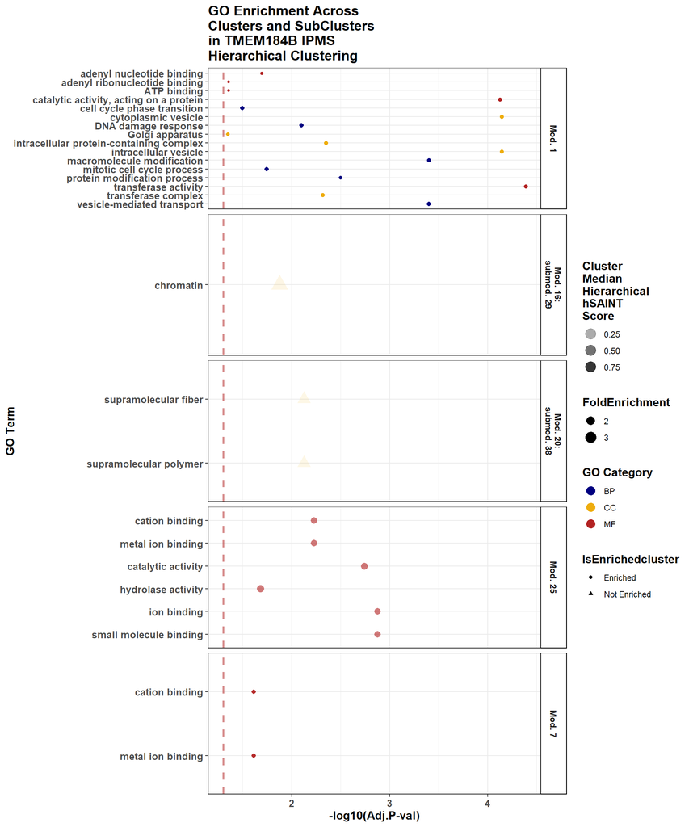

```r
global_enrichment_results_df |>
  dplyr::full_join(subcluster_enrichment_results_df) |>
  dplyr::full_join(cluster_scores) |>
  dplyr::filter(!is.na(GO_Term)) |>
  dplyr::filter(!is.na(GO_Category)) |>
  dplyr::mutate(
    Tier = dplyr::case_when(
      is.na(subcluster) ~ paste0('Mod. ', cluster),
      TRUE ~ paste0('Mod. ', cluster,
                    ':\nsubmod. ',
                    gsub(subcluster, pattern = 'sub', replacement = ''))
      ),
    is_enriched = dplyr::case_when(is.na(subcluster) ~ 'Enriched',
                                   TRUE ~ 'Not Enriched')
    ) |>
  dplyr::group_by(cluster) |>
  dplyr::arrange(p.adjust) |>
  ggplot2::ggplot(
    ggplot2::aes(
      x = -log10(p.adjust),
      y = forcats::fct_rev(forcats::fct_infreq(GO_Term, cluster_median_hSAINT_score)),
      color = GO_Category,
      size = FoldEnrichment,
      alpha = cluster_median_hSAINT_score,
      shape = is_enriched,
    )
  ) +
  ggplot2::geom_vline(xintercept = -log10(0.05),
                      linetype = 'dashed',
                      color = 'firebrick',
                      size = 1,
                      alpha = 0.5) +
  ggplot2::geom_point() +
  ggplot2::facet_grid(Tier ~ ., scales = 'free_y') +
  ggplot2::labs(title = 'GO Enrichment Across\nClusters and SubClusters\nin TMEM184B IPMS\nHierarchical Clustering',
                x = '-log10(Adj.P-val)',
                y = 'GO Term',
                alpha = 'Cluster\nMedian\nHierarchical\nhSAINT\nScore',
                size = 'FoldEnrichment',
                color = 'GO Category',
                shape = 'IsEnrichedcluster') +
  ggplot2::theme_bw() +
  ggplot2::theme(title = ggplot2::element_text(face = 'bold', size = 12),
                 axis.text = ggplot2::element_text(face = 'bold', size = 10),
                 strip.text = ggplot2::element_text(face = 'bold', size = 9),
                 strip.background = ggplot2::element_rect(color = 'black',
                                                          fill = 'white')) +
  ggplot2::guides(#shape = ggplot2::guide_legend(override.aes = list(size = 4, shape = c(19, 17))),
                  color = ggplot2::guide_legend(override.aes = list(size = 4,
                                                                    shape = 19,
                                                                    color = c('navy',
                                                                              'darkgoldenrod2',
                                                                              'firebrick'))),
                  alpha = ggplot2::guide_legend(override.aes = list(size = 5,
                                                                    shape = 19)),
                  size = ggplot2::guide_legend(override.aes = list(shape = 19))
                  # size = 'none'
                  ) +
  ggplot2::scale_color_manual(values = c('navy',
                                         'darkgoldenrod2',
                                        'firebrick')) +
  ggplot2::scale_fill_manual(values = c('navy',
                                        'darkgoldenrod2',
                                        'firebrick'))
```

## Cluster GO (similarity) Network

```r
coords <- igraph::layout_with_fr(g)
coords <- coords*200

visNetwork::visNetwork(
  nodes = data.frame(
    id    = igraph::V(g)$name,
    label = igraph::V(g)$name,
    size = scales::rescale(
      (\(x){ x[is.na(x)] <- 0; x })(igraph::V(g)$cluster_hSAINT_score_mass),
      to = c(20, 60)
    ),
    x = coords[,1],
    y = coords[,2],
    group = base::interaction(
                        {
                          x <- igraph::V(g)$cluster
                          if (length(x) == 0) rep("", igraph::vcount(g)) else x
                        },
                        {
                          x <- igraph::V(g)$subcluster
                          if (length(x) == 0) {
                            rep("", igraph::vcount(g))
                          } else {
                            ifelse(nzchar(x), x, igraph::V(g)$cluster)
                          }
                        },
                        drop = TRUE,
                        lex.order = TRUE
                      ),
    title = sapply(
      igraph::V(g),
      function(v) {
        incoming_edges <- igraph::incident(g, v, mode = "all")
        incoming_edges <- incoming_edges[
          igraph::ends(g, incoming_edges)[,2] == igraph::V(g)[v]$name
        ]
        raw_gene_strings <- igraph::E(g)[incoming_edges]$geneID
        raw_gene_strings <- unlist(raw_gene_strings, use.names = FALSE)

        genes <- raw_gene_strings |>
          as.character() |>
          (\(x) x[!is.na(x)])() |>
          strsplit("\\\\") |>
          unlist() |>
          (\(x) x[nzchar(x)])() |>
          unique()

        term <- igraph::V(g)[v]$name
        saint_value <- igraph::V(g)[v]$cluster_hSAINT_score_mass
        if (is.na(saint_value)) saint_value <- 0
        is_cluster <- nzchar(igraph::V(g)[v]$subcluster)

        if (is_cluster) {
          paste0(
            "<div style='background-color:#ffffff;color:#1f4e79;",
            "padding:6px 10px;border-radius:6px;",
            "border:1px solid #1f4e79;font-size:12px;'>",
            "<b>", term, "</b><br>",
            "<b>SAINT mass:</b> ", signif(saint_value, 3), "<br>",
            if (length(genes) > 0)
              paste0("<u>Proteins:</u><br>", paste(genes, collapse = "<br>"))
            else "",
            "</div>"
          )
        } else {
          paste0(
            "<div style='background-color:#ffffff;color:#1f4e79;",
            "padding:6px 10px;border-radius:6px;",
            "border:1px solid #1f4e79;font-size:12px;'>",
            "<b>", term, "</b><br>",
            if (length(genes) > 0)
              paste0("<u>Proteins:</u><br>", paste(genes, collapse = "<br>"))
            else "",
            "</div>"
          )
        }
      }
    )
  ),
  edges = data.frame(
    from  = igraph::as_data_frame(g, "edges")$from,
    to    = igraph::as_data_frame(g, "edges")$to,
    value = igraph::E(g)$weight,
    title = vapply(
      seq_along(igraph::E(g)),
      function(i) {
        paste0(
          "<div style='background-color:#ffffff;color:#1f4e79;",
          "padding:6px 10px;border-radius:6px;",
          "border:1px solid #1f4e79;font-size:12px;'>",
          "<b>p.adjust:</b> ", signif(igraph::E(g)$p.adjust[i], 3), "<br>",
          "<b>weight:</b> ", signif(igraph::E(g)$weight[i], 3),
          "</div>"
        )
      },
      FUN.VALUE = character(1)
    )
  )
) |>
  # visNetwork::visNodes(color = NULL) |>
  visNetwork::visEdges(arrows = "to") |>
  visNetwork::visNodes(
    scaling = list(min = 5, max = 40),
    shadow  = TRUE
  ) |>
  visNetwork::visLayout(randomSeed = 1) |>
  visNetwork::visPhysics(enabled = FALSE) |>
  visNetwork::visInteraction(
    dragView = TRUE,
    zoomView = TRUE
  ) |>
  visNetwork::visOptions(nodesIdSelection = TRUE)
```

[interactive chart not shown]

```r
rm(coords)
```

## Heatmaps

### Raw Counts Heatmap

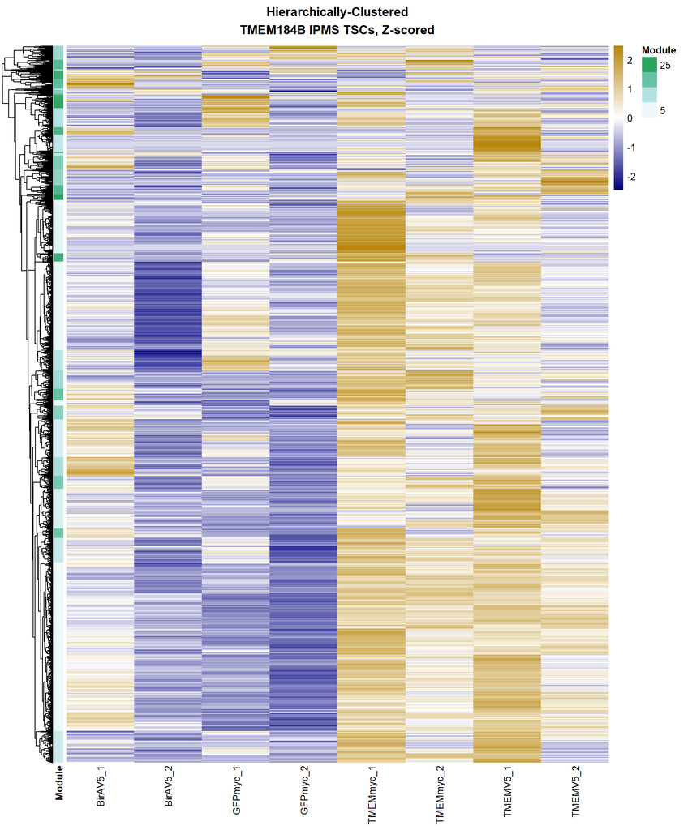

```r
pheatmap::pheatmap(
  IPMS_z_ordered,
  color = grDevices::colorRampPalette(c('navy',
                                        'white',
                                        'darkgoldenrod'))((200)),
  cluster_rows = hc,
  cluster_cols = F,
  show_rownames = F,
  annotation_row = data.frame(Module = clusters_opt),
  annotation_colors = annotation_colors,
  angle_col = 90,
  use_raster = F,
  border_color = NA,
  main = 'Hierarchically-Clustered\nTMEM184B IPMS TSCs, Z-scored'
)
```

### Raw Counts Heatmap (TMEM Cluster)

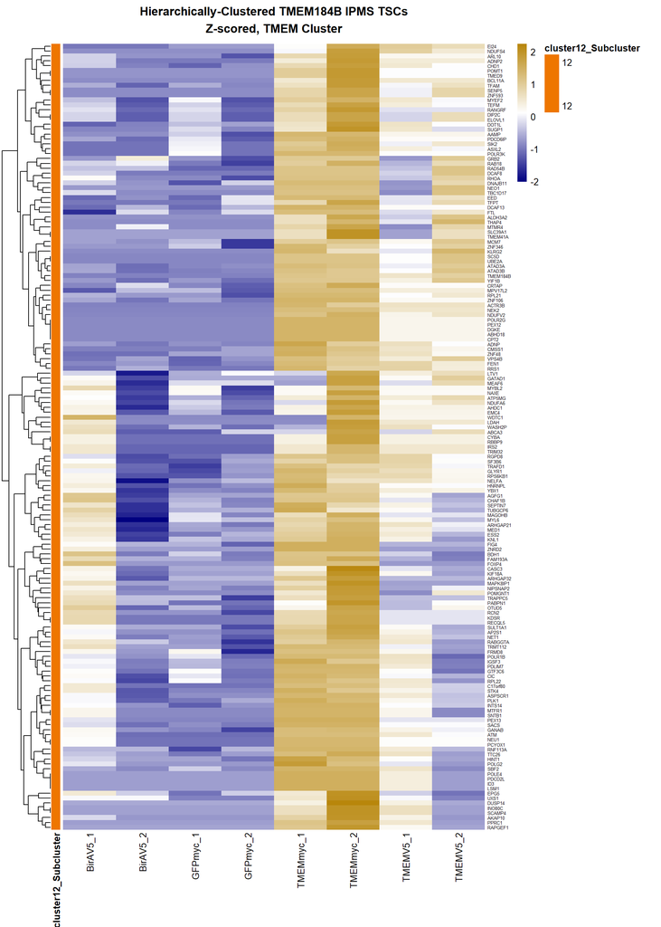

```r
pheatmap::pheatmap(
  IPMS_z_ordered[rownames(IPMS_z_ordered) %in%

                   c(protein_cluster_df |>
                       dplyr::full_join(global_enrichment_results_df) |>
                       dplyr::full_join(subcluster_enrichment_results_df) |>
                       dplyr::select(-c(GO_Category:Count)) |>
                       dplyr::distinct() |>
                       dplyr::filter(
                         cluster == protein_cluster_df |>
                           dplyr::full_join(global_enrichment_results_df) |>
                           dplyr::full_join(subcluster_enrichment_results_df) |>
                           dplyr::select(-c(GO_Category:Count)) |>
                           dplyr::filter(Protein == 'TMEM184B') |>
                           dplyr::pull(cluster)
                         ) |>
                       dplyr::pull(Protein)
                     ),
                 ],
  color = grDevices::colorRampPalette(c('navy',
                                        'white',
                                        'darkgoldenrod'))((200)),
  cluster_rows = T,
  cluster_cols = F,
  show_rownames = T,
  fontsize_row = 5,
  annotation_row = data.frame(

    cluster12_Subcluster = clusters_opt[
      names(clusters_opt) %in%

        c(protein_cluster_df |>
                       dplyr::full_join(global_enrichment_results_df) |>
                       dplyr::full_join(subcluster_enrichment_results_df) |>
                       dplyr::select(-c(GO_Category:Count)) |>
                       dplyr::distinct() |>
                       dplyr::filter(
                         cluster == protein_cluster_df |>
                           dplyr::full_join(global_enrichment_results_df) |>
                           dplyr::full_join(subcluster_enrichment_results_df) |>
                           dplyr::select(-c(GO_Category:Count)) |>
                           dplyr::filter(Protein == 'TMEM184B') |>
                           dplyr::pull(cluster)
                         ) |> dplyr::filter(!is.na(Protein)) |>
            dplyr::pull(Protein)
                     )
      ]
    ),
  annotation_colors = list(cluster12_Subcluster = 'darkorange2'),
  angle_col = 90,
  use_raster = F,
  border_color = NA,
  main = 'Hierarchically-Clustered TMEM184B IPMS TSCs\nZ-scored, TMEM Cluster'
)
```

- **TMEM**’s cluster (**12**) is not siginficantly enriched above the proteins detected by the mass spectrometer
- Subclusters within **cluster 12** are not enriched

### High hSAINT Score, Low Contamination Cluster Heatmap (Clear Signal)

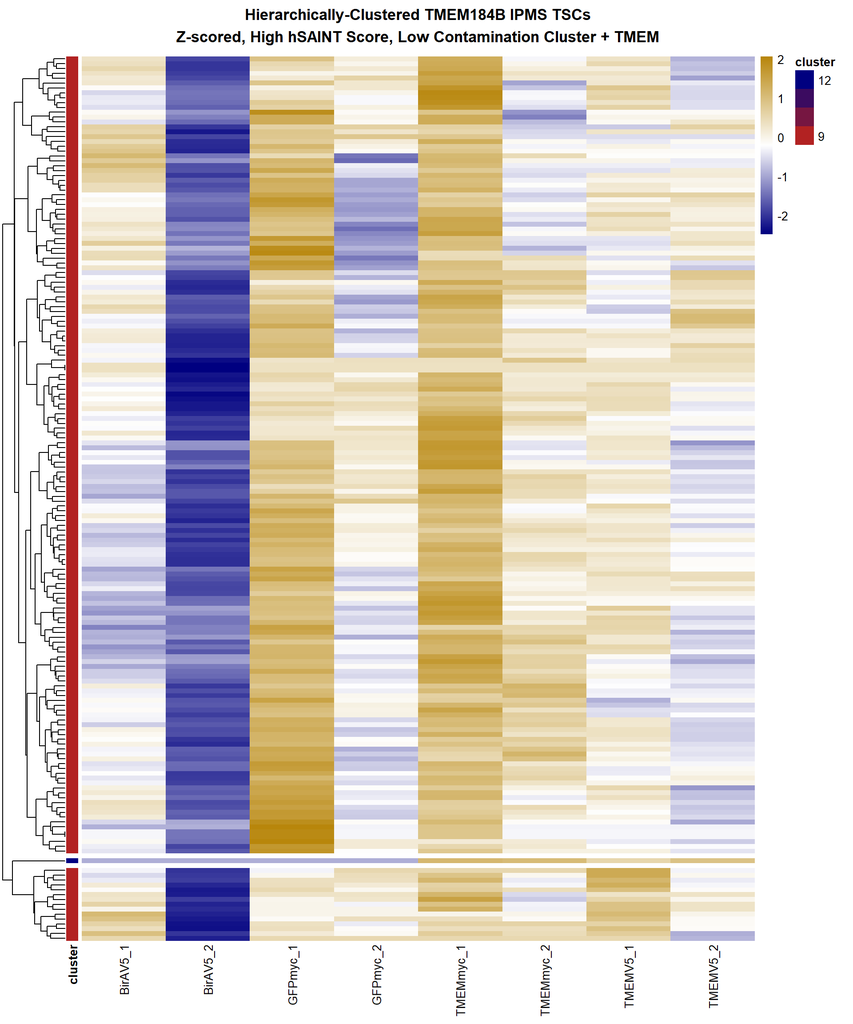

```r
pheatmap::pheatmap(
  IPMS_z_ordered[rownames(IPMS_z_ordered) %in% c(protein_cluster_df |>
                   dplyr::filter(Protein == 'TMEM184B' |
                                   grepl(cluster_class,
                                         pattern = 'High hSAINT, Low')) |>
                   dplyr::pull(Protein)),],
  color = grDevices::colorRampPalette(c('navy',
                                        'white',
                                        'darkgoldenrod'))((200)),
  cluster_rows = T,
  cluster_cols = F,
  show_rownames = F,
  annotation_row = data.frame(

    cluster = clusters_opt[
      names(clusters_opt) %in%

        c(protein_cluster_df |>
            dplyr::filter(Protein == 'TMEM184B' |
                            grepl(cluster_class,
                                  pattern = 'High hSAINT, Low')) |>
            dplyr::pull(Protein)
          )
      ]
    ),

  annotation_colors = list(cluster = c('firebrick', 'navy')),
  angle_col = 90,
  use_raster = F,
  border_color = NA,
  cutree_rows = 3,
  main = 'Hierarchically-Clustered TMEM184B IPMS TSCs\nZ-scored, High hSAINT Score, Low Contamination Cluster + TMEM'
)
```

### High hSAINT Score, Medium Contamination Cluster Heatmap

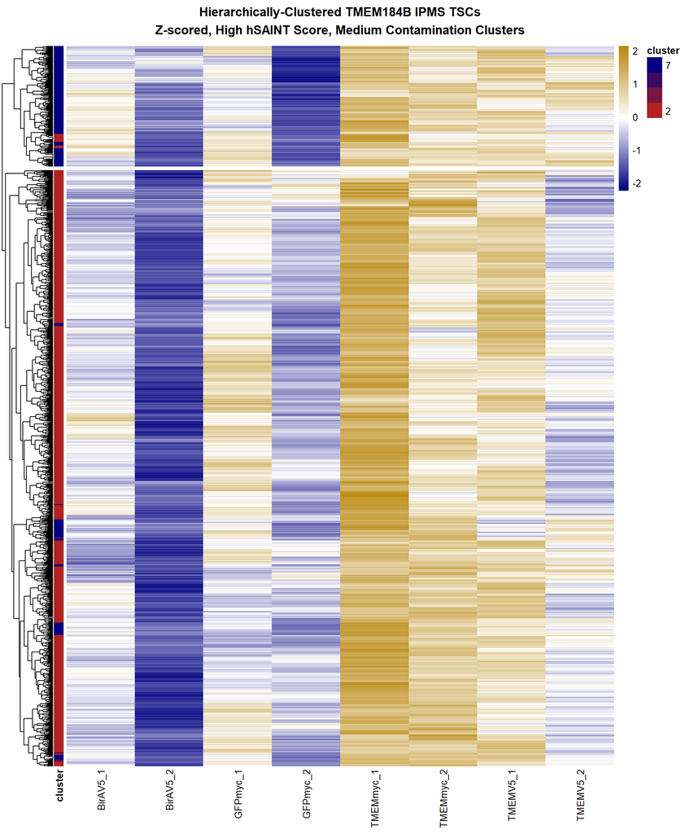

```r
pheatmap::pheatmap(
  IPMS_z_ordered[rownames(IPMS_z_ordered) %in% c(protein_cluster_df |>
                   dplyr::filter(grepl(cluster_class,
                                         pattern = 'High hSAINT, Med')) |>
                   dplyr::pull(Protein)),],
  color = grDevices::colorRampPalette(c('navy',
                                        'white',
                                        'darkgoldenrod'))((200)),
  cluster_rows = T,
  cluster_cols = F,
  show_rownames = F,
  annotation_row = data.frame(

    cluster = clusters_opt[
      names(clusters_opt) %in%

        c(protein_cluster_df |>
            dplyr::filter(grepl(cluster_class,
                                  pattern = 'High hSAINT, Med')) |>
            dplyr::pull(Protein)
          )
      ]
    ),

  annotation_colors = list(cluster = c('firebrick', 'navy')),
  angle_col = 90,
  use_raster = F,
  border_color = NA,
  cutree_rows = 2,
  main = 'Hierarchically-Clustered TMEM184B IPMS TSCs\nZ-scored, High hSAINT Score, Medium Contamination Clusters'
)
```

### High hSAINT Score, High Contamination Clusters Heatmap (Sticky/Noise)

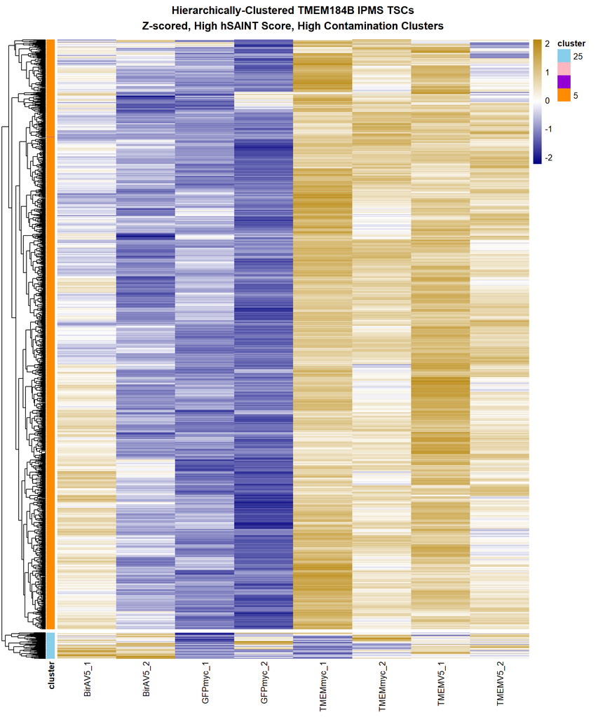

```r
pheatmap::pheatmap(
  IPMS_z_ordered[rownames(IPMS_z_ordered) %in% c(protein_cluster_df |>
                   dplyr::filter(Protein == 'TMEM184B' |
                                   grepl(cluster_class,
                                         pattern = 'High hSAINT, High')) |>
                   dplyr::pull(Protein)),],
  color = grDevices::colorRampPalette(c('navy',
                                        'white',
                                        'darkgoldenrod'))((200)),
  cluster_rows = T,
  cluster_cols = F,
  show_rownames = F,
  annotation_row = data.frame(

    cluster = clusters_opt[
      names(clusters_opt) %in%

        c(protein_cluster_df |>
            dplyr::filter(Protein == 'TMEM184B' |
                            grepl(cluster_class,
                                  pattern = 'High hSAINT, High')) |>
            dplyr::pull(Protein)
          )
      ]
    ),

  annotation_colors = list(cluster = c('darkorange',
                                      'darkviolet',
                                      'lightpink',
                                      'skyblue')),
  angle_col = 90,
  use_raster = F,
  border_color = NA,
  cutree_rows = 2,
  main = 'Hierarchically-Clustered TMEM184B IPMS TSCs\nZ-scored, High hSAINT Score, High Contamination Clusters'
)
```

### Low hSAINT Score, Low Contamination Clusters Heatmap (Low Abundance)

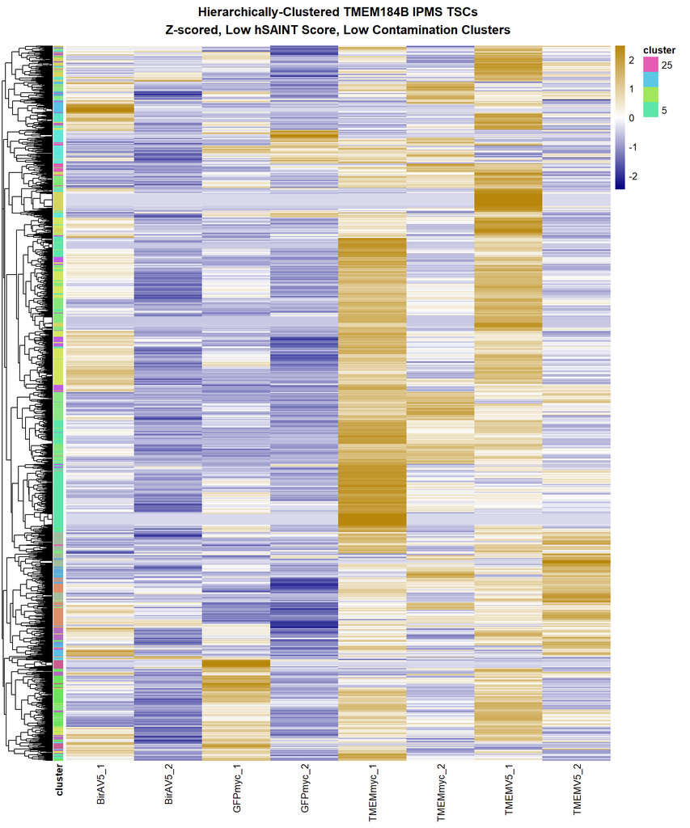

```r
pheatmap::pheatmap(
  IPMS_z_ordered[rownames(IPMS_z_ordered) %in% c(protein_cluster_df |>
                   dplyr::filter(grepl(cluster_class,
                                         pattern = 'Low hSAINT, Low')) |>
                   dplyr::pull(Protein)),],
  color = grDevices::colorRampPalette(c('navy',
                                        'white',
                                        'darkgoldenrod'))((200)),
  cluster_rows = T,
  cluster_cols = F,
  show_rownames = F,
  annotation_row = data.frame(

    cluster = clusters_opt[
      names(clusters_opt) %in%

        c(protein_cluster_df |>
            dplyr::filter(Protein == 'TMEM184B' |
                            grepl(cluster_class,
                                  pattern = 'Low hSAINT, Low')) |>
            dplyr::pull(Protein)
          )
      ]
    ),

  annotation_colors = list(cluster = annotation_colors[[1]][
    clusters_opt[
      names(clusters_opt) %in% c(protein_cluster_df |>
                   dplyr::filter(grepl(cluster_class,
                                         pattern = 'Low hSAINT, Low')) |>
                   dplyr::pull(Protein))
    ] |> as.numeric() |> unique()
  ]),
  angle_col = 90,
  use_raster = F,
  border_color = NA,
  main = 'Hierarchically-Clustered TMEM184B IPMS TSCs\nZ-scored, Low hSAINT Score, Low Contamination Clusters'
)
```

### Low hSAINT Score, Medium Contamination Clusters Heatmap

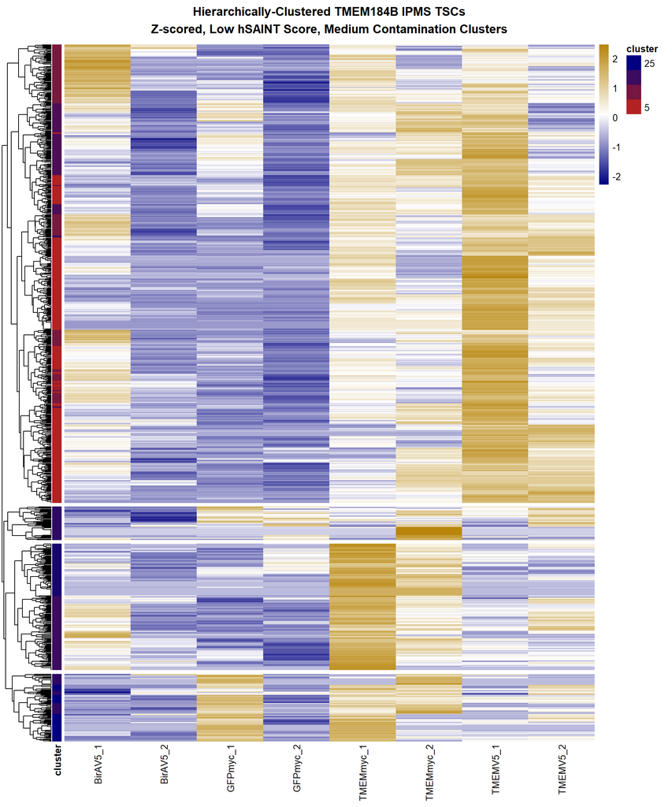

```r
pheatmap::pheatmap(
  IPMS_z_ordered[rownames(IPMS_z_ordered) %in% c(protein_cluster_df |>
                   dplyr::filter(grepl(cluster_class,
                                         pattern = 'Low hSAINT, Med')) |>
                   dplyr::pull(Protein)),],
  color = grDevices::colorRampPalette(c('navy',
                                        'white',
                                        'darkgoldenrod'))((200)),
  cluster_rows = T,
  cluster_cols = F,
  show_rownames = F,
  annotation_row = data.frame(

    cluster = clusters_opt[
      names(clusters_opt) %in%

        c(protein_cluster_df |>
            dplyr::filter(grepl(cluster_class,
                                  pattern = 'Low hSAINT, Med')) |>
            dplyr::pull(Protein)
          )
      ]
    ),

  annotation_colors = list(cluster = c('firebrick', 'navy')),
  angle_col = 90,
  use_raster = F,
  border_color = NA,
  cutree_rows = 4,
  main = 'Hierarchically-Clustered TMEM184B IPMS TSCs\nZ-scored, Low hSAINT Score, Medium Contamination Clusters'
)
```

# Results Tables

## Clustering Results Table by Protein (Cluster 1, first 3000 rows)

```r
DT::datatable(
  protein_cluster_df |>
    dplyr::full_join(global_enrichment_results_df |>
                       dplyr::select(-c(cluster_mean_hSAINT_score:cluster_CRAPome_flag_perc))) |>
    dplyr::full_join(subcluster_enrichment_results_df |>
                       dplyr::select(-c(cluster_mean_hSAINT_score:cluster_CRAPome_flag_perc))) |>
    dplyr::filter(!is.na(GO_Term)) |>
    dplyr::filter(!is.na(GO_Category)) |>
    dplyr::distinct() |>
    dplyr::filter(cluster == 1 &
                    grepl(protein_stat_class, pattern = 'Low Contam') &
                    protein_hSAINT_score > 0.5 &
                    protein_contam_flag == 0) |>
    dplyr::slice_head(n = 3000)
)
```

|  | Protein | cluster | cluster_class | protein_hSAINT_score | protein_contam_flag | protein_lit_flag | protein_CRAPome_flag | protein_stat_class | cluster_mean_hSAINT_score | cluster_median_hSAINT_score | cluster_hSAINT_score_mass | cluster_size | cluster_contam_perc | cluster_mean_rank | cluster_median_rank | cluster_total_rank | cluster_lit_flag_perc | cluster_CRAPome_flag_perc | GO_Category | GO_ID | GO_Term | GeneRatio | BgRatio | RichFactor | FoldEnrichment | zScore | pvalue | p.adjust | qvalue | … |
| --- | --- | --- | --- | --- | --- | --- | --- | --- | --- | --- | --- | --- | --- | --- | --- | --- | --- | --- | --- | --- | --- | --- | --- | --- | --- | --- | --- | --- | --- | --- |
| 1 | AAAS | 1 | High hSAINT, High Contamination | 1 | 0 | 0 | 0 | High hSAINT, Low Contamination | 0.689 | 0.985 | 1084.001 | 1574 | 13.405 | 2 | 2 | 1 | 8.704 | 4.701 | CC | GO:0005794 | Golgi apparatus | 148/1336 | 157/1546 | 0.9426751592356688 | 1.090850146840078 | 3.028183303188706 | 0.000804708022651197 | 0.04458082445487632 | 0.04048951945550234 | … |
| 2 | AAAS | 1 | High hSAINT, High Contamination | 1 | 0 | 0 | 0 | High hSAINT, Low Contamination | 0.689 | 0.985 | 1084.001 | 1574 | 13.405 | 2 | 2 | 1 | 8.704 | 4.701 | MF | GO:0032559 | adenyl ribonucleotide binding | 260/1323 | 282/1531 | 0.9219858156028369 | 1.066938989937977 | 3.137736428852473 | 0.0006913022406914201 | 0.04404508437057008 | 0.03924261154625967 | … |
| 3 | AAAS | 1 | High hSAINT, High Contamination | 1 | 0 | 0 | 0 | High hSAINT, Low Contamination | 0.689 | 0.985 | 1084.001 | 1574 | 13.405 | 2 | 2 | 1 | 8.704 | 4.701 | MF | GO:0005524 | ATP binding | 259/1323 | 281/1531 | 0.9217081850533808 | 1.066617710745825 | 3.115887923348885 | 0.0007516226001803768 | 0.04404508437057008 | 0.03924261154625967 | … |
| 4 | AAAS | 1 | High hSAINT, High Contamination | 1 | 0 | 0 | 0 | High hSAINT, Low Contamination | 0.689 | 0.985 | 1084.001 | 1574 | 13.405 | 2 | 2 | 1 | 8.704 | 4.701 | BP | GO:0044770 | cell cycle phase transition | 77/1311 | 78/1517 | 0.9871794871794872 | 1.142296935203114 | 3.254091699010312 | 0.0001155180617542313 | 0.03203700912650682 | 0.03054135422168888 | … |
| 5 | AAAS | 1 | High hSAINT, High Contamination | 1 | 0 | 0 | 0 | High hSAINT, Low Contamination | 0.689 | 0.985 | 1084.001 | 1574 | 13.405 | 2 | 2 | 1 | 8.704 | 4.701 | MF | GO:0030554 | adenyl nucleotide binding | 282/1323 | 305/1531 | 0.9245901639344263 | 1.069952789859113 | 3.441943161411369 | 0.0002071236059140009 | 0.02022907217760076 | 0.01802338746199026 | … |
| 6 | AAAS | 1 | High hSAINT, High Contamination | 1 | 0 | 0 | 0 | High hSAINT, Low Contamination | 0.689 | 0.985 | 1084.001 | 1574 | 13.405 | 2 | 2 | 1 | 8.704 | 4.701 | BP | GO:1903047 | mitotic cell cycle process | 109/1311 | 112/1517 | 0.9732142857142857 | 1.126137354255203 | 3.498097442062972 | 5.389191636237099e-05 | 0.01793522976539707 | 0.01709791957012486 | … |
| 7 | AAAS | 1 | High hSAINT, High Contamination | 1 | 0 | 0 | 0 | High hSAINT, Low Contamination | 0.689 | 0.985 | 1084.001 | 1574 | 13.405 | 2 | 2 | 1 | 8.704 | 4.701 | BP | GO:0006974 | DNA damage response | 129/1311 | 133/1517 | 0.9699248120300752 | 1.12233099912252 | 3.724874410980861 | 1.902954849835296e-05 | 0.007916292175314832 | 0.007546718312373135 | … |
| 8 | AAAS | 1 | High hSAINT, High Contamination | 1 | 0 | 0 | 0 | High hSAINT, Low Contamination | 0.689 | 0.985 | 1084.001 | 1574 | 13.405 | 2 | 2 | 1 | 8.704 | 4.701 | CC | GO:1990234 | transferase complex | 130/1336 | 135/1546 | 0.9629629629629629 | 1.114326901752051 | 3.505981622245407 | 6.993305263966026e-05 | 0.004842863895296473 | 0.004398420942336527 | … |
| 9 | AAAS | 1 | High hSAINT, High Contamination | 1 | 0 | 0 | 0 | High hSAINT, Low Contamination | 0.689 | 0.985 | 1084.001 | 1574 | 13.405 | 2 | 2 | 1 | 8.704 | 4.701 | CC | GO:0140535 | intracellular protein-containing complex | 133/1336 | 138/1546 | 0.9637681159420289 | 1.115258613208366 | 3.577415869728075 | 4.849745722503501e-05 | 0.004477931883778233 | 0.004066979746239779 | … |
| 10 | AAAS | 1 | High hSAINT, High Contamination | 1 | 0 | 0 | 0 | High hSAINT, Low Contamination | 0.689 | 0.985 | 1084.001 | 1574 | 13.405 | 2 | 2 | 1 | 8.704 | 4.701 | BP | GO:0036211 | protein modification process | 241/1311 | 255/1517 | 0.9450980392156862 | 1.093603146826999 | 4.132836253660271 | 5.686184364481749e-06 | 0.00315393692749921 | 0.003006694679745262 | … |

[output cut: 2990 more lines]

- This (complete) table exists as hClust_protein_level_GO_GSEA.rda in Endo/analysis/R/hClust/

## Clustering Results Table by Cluster

```r
DT::datatable(
  global_enrichment_results_df |>
    dplyr::full_join(subcluster_enrichment_results_df) |>
    dplyr::full_join(cluster_scores) |>
    dplyr::arrange(p.adjust, FoldEnrichment) |>
    dplyr::filter(!is.na(GO_Term))
)
```

|  | cluster | GO_Category | cluster_class | GO_ID | GO_Term | GeneRatio | BgRatio | RichFactor | FoldEnrichment | zScore | pvalue | p.adjust | qvalue | geneID | Count | cluster_mean_hSAINT_score | cluster_median_hSAINT_score | cluster_hSAINT_score_mass | cluster_size | cluster_contam_perc | cluster_mean_rank | cluster_median_rank | cluster_total_rank | cluster_lit_flag_perc | cluster_CRAPome_flag_perc | subcluster |
| --- | --- | --- | --- | --- | --- | --- | --- | --- | --- | --- | --- | --- | --- | --- | --- | --- | --- | --- | --- | --- | --- | --- | --- | --- | --- | --- |
| 1 | 1 | MF | High hSAINT, High Contamination | GO:0016740 | transferase activity | 273/1323 | 287/1531 | 0.9512195121951219 | 1.100768762789669 | 4.774750189834185 | 1.391422315064724e-07 | 4.076867383139641e-05 | 3.632344569853174e-05 | ACAT1/ADCK1/AGK/AGPAT1/AGPAT5/AGPS/AK4/AK6/AKT2/ALG1/AMFR/AR…… | 273 | 0.6886917717199464 | 0.9852949271252127 | 1084.000848687196 | 1574 | 13.40533672172808 | 2 | 2 | 1 | 8.703939008894537 | 4.701397712833545 |  |
| 2 | 1 | CC | High hSAINT, High Contamination | GO:0031410 | cytoplasmic vesicle | 243/1336 | 255/1546 | 0.9529411764705882 | 1.10272983444875 | 4.526488078593894 | 5.162013830765747e-07 | 7.14938915561056e-05 | 6.493270029226388e-05 | ABCB6/ABCC4/ABHD6/ACTG1/ACTR10/ACTR1B/AKT2/AMBRA1/ANKFY1/ANK…… | 243 | 0.6886917717199464 | 0.9852949271252127 | 1084.000848687196 | 1574 | 13.40533672172808 | 2 | 2 | 1 | 8.703939008894537 | 4.701397712833545 |  |
| 3 | 1 | CC | High hSAINT, High Contamination | GO:0097708 | intracellular vesicle | 243/1336 | 255/1546 | 0.9529411764705882 | 1.10272983444875 | 4.526488078593894 | 5.162013830765747e-07 | 7.14938915561056e-05 | 6.493270029226388e-05 | ABCB6/ABCC4/ABHD6/ACTG1/ACTR10/ACTR1B/AKT2/AMBRA1/ANKFY1/ANK…… | 243 | 0.6886917717199464 | 0.9852949271252127 | 1084.000848687196 | 1574 | 13.40533672172808 | 2 | 2 | 1 | 8.703939008894537 | 4.701397712833545 |  |
| 4 | 1 | MF | High hSAINT, High Contamination | GO:0140096 | catalytic activity, acting on a protein | 233/1323 | 244/1531 | 0.9549180327868853 | 1.105048759030024 | 4.512222804250781 | 5.115472634413541e-07 | 7.494167409415837e-05 | 6.677037964918726e-05 | ABHD12/ADCK1/AGTPBP1/AKT2/AMFR/AMZ2/APEH/ARAF/ARF4/ARIH1/ATG…… | 233 | 0.6886917717199464 | 0.9852949271252127 | 1084.000848687196 | 1574 | 13.40533672172808 | 2 | 2 | 1 | 8.703939008894537 | 4.701397712833545 |  |
| 5 | 1 | BP | High hSAINT, High Contamination | GO:0043412 | macromolecule modification | 272/1311 | 287/1517 | 0.9477351916376306 | 1.096654680178708 | 4.585942626470527 | 4.790128990298232e-07 | 0.0003985387319928129 | 0.0003799328625462861 | ABCE1/ABHD12/ABRAXAS2/ADAR/AGTPBP1/AKT2/ALG1/AMBRA1/AMFR/ANA…… | 272 | 0.6886917717199464 | 0.9852949271252127 | 1084.000848687196 | 1574 | 13.40533672172808 | 2 | 2 | 1 | 8.703939008894537 | 4.701397712833545 |  |
| 6 | 1 | BP | High hSAINT, High Contamination | GO:0016192 | vesicle-mediated transport | 173/1311 | 178/1517 | 0.9719101123595506 | 1.124628253584621 | 4.463274095521752 | 2.731627848243966e-07 | 0.0003985387319928129 | 0.0003799328625462861 | ABCC4/ACTG1/ACTR1A/ANKFY1/ANKRD27/AP1S2/AP3S2/AP5B1/ARCN1/AR…… | 173 | 0.6886917717199464 | 0.9852949271252127 | 1084.000848687196 | 1574 | 13.40533672172808 | 2 | 2 | 1 | 8.703939008894537 | 4.701397712833545 |  |
| 7 | 25 | MF | High hSAINT, High Contamination | GO:0043167 | ion binding | 23/44 | 25/69 | 0.92 | 1.442727272727273 | 3.650822617592365 | 0.0001564334933483454 | 0.001329684693460936 | 0.0008233341755176075 | ARG1/CALML5/CAT/COL1A2/CP/CPA4/DSC1/DSC3/DSG1/FABP5/FEM1B/FLG/FLG2/GSDMA/HARS2/HRNR/LTF/PLPBP/S100A7/TGM1/TGM3/ZBED5/ZC3H8 | 23 | 0.5327028180546081 | 0.5612785130131066 | 37.28919726382257 | 70 | 35.71428571428572 | 5 | 5 | 15 | 35.71428571428572 | 0 |  |
| 8 | 25 | MF | High hSAINT, High Contamination | GO:0036094 | small molecule binding | 24/44 | 26/69 | 0.9230769230769231 | 1.447552447552447 | 3.807212984675886 | 8.038415287758968e-05 | 0.001329684693460936 | 0.0008233341755176075 | ARG1/CALML5/CAT/COL1A2/CP/CPA4/DSC1/DSC3/DSG1/FABP5/FEM1B/FLG/FLG2/GDPGP1/GSDMA/HARS2/HRNR/LTF/PLPBP/S100A7/TGM1/TGM3/ZBED5/ZC3H8 | 24 | 0.5327028180546081 | 0.5612785130131066 | 37.28919726382257 | 70 | 35.71428571428572 | 5 | 5 | 15 | 35.71428571428572 | 0 |  |
| 9 | 25 | MF | High hSAINT, High Contamination | GO:0003824 | catalytic activity | 19/44 | 20/69 | 0.95 | 1.489772727272727 | 3.423121751149248 | 0.0003198238481032331 | 0.001812335139251654 | 0.001122188940713099 | ARG1/AZGP1/CAT/CP/CPA4/CTDSPL2/CTSD/GDPGP1/HAL/HARS2/LTF/MBOAT2/NCCRP1/PAFAH1B2/PIP/RPP38/TAF10/TGM1/TGM3 | 19 | 0.5327028180546081 | 0.5612785130131066 | 37.28919726382257 | 70 | 35.71428571428572 | 5 | 5 | 15 | 35.71428571428572 | 0 |  |
| 10 | 1 | BP | High hSAINT, High Contamination | GO:0036211 | protein modification process | 241/1311 | 255/1517 | 0.9450980392156862 | 1.093603146826999 | 4.132836253660271 | 5.686184364481749e-06 | 0.00315393692749921 | 0.003006694679745262 | ABCE1/ABRAXAS2/ADAR/AGTPBP1/AKT2/ALG1/AMBRA1/AMFR/ANAPC2/ANA…… | 241 | 0.6886917717199464 | 0.9852949271252127 | 1084.000848687196 | 1574 | 13.40533672172808 | 2 | 2 | 1 | 8.703939008894537 | 4.701397712833545 |  |

[output cut: 17 more lines]

- This table exists as hClust_cluster_level_GO_GSEA.rda in Endo/analysis/R/hClust/

# Summary

- **Cluster 1** has the highest volume of `hSAINT` signal across clusters, with some interesting potential candidates
- As noted above, it is not surprising **Cluster 12**, **TMEM**’s cluster, was not enriched, containing a large amount of proteins with low `hSAINT` scores, likely due to **TMEM**’s nature as a transmembrane protein, exacerbated by its localization to multiple organellar compartments
- A more in-depth analysis of proteins across clusters, on a protein-by-protein basis, where there is greater probability of interacting with **TMEM** is encouraged
  - Collecting groups of proteins, related by localization or function, is useful for inferring data validity; however, positive or negative data coherence **should not negate** investigating proteins with high `hSAINT` scores or are known/likely to interact with `TMEM` or related processes
- Collectively, it appears the `hierarchical SAINT` model has done a fair job at delineating possible signal from noise
- Multi-modal statistical coherence is designed to compare the clustering method with the most merit in characterizing groups of proteins more likely to be identified as true interactors of **TMEM184B**, in support of the `hierarchical Poisson latent mixture model`